# Unsupervised Learning

### Dataset Used: [Mall Customer Segmentation Data](https://www.kaggle.com/datasets/vjchoudhary7/customer-segmentation-tutorial-in-python/data)

## 1. Import required libraries

```python
# Import libraries for data manipulation
import numpy as np
import pandas as pd

# Import visualization libraries
import matplotlib.pyplot as plt
import seaborn as sns

# Import data preprocessing libraries
from sklearn.preprocessing import StandardScaler # For feature scaling
from sklearn.preprocessing import LabelEncoder # For encoding categorical columns

# Import machine learning models
from sklearn.cluster import KMeans, DBSCAN

import random
from sklearn.metrics import silhouette_score
from sklearn.model_selection import GridSearchCV
```

```python
# Ignore warnings
import warnings
warnings.filterwarnings("ignore")
```

## 2. Load dataset

```python
# Read CSV file into a dataframe
mall_data = pd.read_csv("Mall_Customers.csv")
```

## 3. Data exploration

```python
# Show first five rows
mall_data.head()
```

|  | CustomerID | Gender | Age | Annual Income (k$) | Spending Score (1-100) |
| --- | --- | --- | --- | --- | --- |
| 0 | 1 | Male | 19 | 15 | 39 |
| 1 | 2 | Male | 21 | 15 | 81 |
| 2 | 3 | Female | 20 | 16 | 6 |
| 3 | 4 | Female | 23 | 16 | 77 |
| 4 | 5 | Female | 31 | 17 | 40 |

```python
# Show final five rows
mall_data.tail()
```

|  | CustomerID | Gender | Age | Annual Income (k$) | Spending Score (1-100) |
| --- | --- | --- | --- | --- | --- |
| 195 | 196 | Female | 35 | 120 | 79 |
| 196 | 197 | Female | 45 | 126 | 28 |
| 197 | 198 | Male | 32 | 126 | 74 |
| 198 | 199 | Male | 32 | 137 | 18 |
| 199 | 200 | Male | 30 | 137 | 83 |

```python
# Show number of rows and columns
mall_data.shape
```

```
(200, 5)
```

```python
# Show column names
mall_data.columns
```

```
Index(['CustomerID', 'Gender', 'Age', 'Annual Income (k$)',
       'Spending Score (1-100)'],
      dtype='object')
```

```python
# Show datatype
mall_data.dtypes
```

```
CustomerID                 int64
Gender                    object
Age                        int64
Annual Income (k$)         int64
Spending Score (1-100)     int64
dtype: object
```

There are 5 columns:

- `Customer ID` - numerical - unique customer number - integer
- `Gender` - categorical - binary (Male/Female)
- `Age` - numerical - integer
- `Annual Income (k$)` - numerical - integer
- `Spending Score (1-100)` - numerical - integer

```python
# Show dataframe information including datatype and non-null count
mall_data.info()
```

```
<class 'pandas.core.frame.DataFrame'>
RangeIndex: 200 entries, 0 to 199
Data columns (total 5 columns):
 #   Column                  Non-Null Count  Dtype
---  ------                  --------------  -----
 0   CustomerID              200 non-null    int64
 1   Gender                  200 non-null    object
 2   Age                     200 non-null    int64
 3   Annual Income (k$)      200 non-null    int64
 4   Spending Score (1-100)  200 non-null    int64
dtypes: int64(4), object(1)
memory usage: 7.9+ KB
```

```python
# Statictical summary of numerical columns
mall_data.describe()
```

|  | CustomerID | Age | Annual Income (k$) | Spending Score (1-100) |
| --- | --- | --- | --- | --- |
| count | 200.000000 | 200.000000 | 200.000000 | 200.000000 |
| mean | 100.500000 | 38.850000 | 60.560000 | 50.200000 |
| std | 57.879185 | 13.969007 | 26.264721 | 25.823522 |
| min | 1.000000 | 18.000000 | 15.000000 | 1.000000 |
| 25% | 50.750000 | 28.750000 | 41.500000 | 34.750000 |
| 50% | 100.500000 | 36.000000 | 61.500000 | 50.000000 |
| 75% | 150.250000 | 49.000000 | 78.000000 | 73.000000 |
| max | 200.000000 | 70.000000 | 137.000000 | 99.000000 |

## 4. Data Preprocessing and Visualization

### 4.1. Data Cleaning

```python
# Check duplicate values
duplicated_values = mall_data.duplicated().sum()
duplicated_values
```

```
np.int64(0)
```

```python
# Check missing values
missing_values = mall_data.isnull().sum()
missing_values
```

```
CustomerID                0
Gender                    0
Age                       0
Annual Income (k$)        0
Spending Score (1-100)    0
dtype: int64
```

#### I will be dropping the CustomerID column since it just contains the index and is not needed.

```python
# Drop CustomerID column
X = mall_data.drop(columns=['CustomerID'])
```

```python
X.info()
```

```
<class 'pandas.core.frame.DataFrame'>
RangeIndex: 200 entries, 0 to 199
Data columns (total 4 columns):
 #   Column                  Non-Null Count  Dtype
---  ------                  --------------  -----
 0   Gender                  200 non-null    object
 1   Age                     200 non-null    int64
 2   Annual Income (k$)      200 non-null    int64
 3   Spending Score (1-100)  200 non-null    int64
dtypes: int64(3), object(1)
memory usage: 6.4+ KB
```

```python
X.head()
```

|  | Gender | Age | Annual Income (k$) | Spending Score (1-100) |
| --- | --- | --- | --- | --- |
| 0 | Male | 19 | 15 | 39 |
| 1 | Male | 21 | 15 | 81 |
| 2 | Female | 20 | 16 | 6 |
| 3 | Female | 23 | 16 | 77 |
| 4 | Female | 31 | 17 | 40 |

### 4.2. Encoding Categorical Columns

```python
categorical_columns = ['Gender']

# Initilize label encoder
label_encoder = LabelEncoder()

# Fit and transform encoder on data
X['Gender'] = label_encoder.fit_transform(X[categorical_columns])
```

```python
X.head()
```

|  | Gender | Age | Annual Income (k$) | Spending Score (1-100) |
| --- | --- | --- | --- | --- |
| 0 | 1 | 19 | 15 | 39 |
| 1 | 1 | 21 | 15 | 81 |
| 2 | 0 | 20 | 16 | 6 |
| 3 | 0 | 23 | 16 | 77 |
| 4 | 0 | 31 | 17 | 40 |

```python
X.info()
```

```
<class 'pandas.core.frame.DataFrame'>
RangeIndex: 200 entries, 0 to 199
Data columns (total 4 columns):
 #   Column                  Non-Null Count  Dtype
---  ------                  --------------  -----
 0   Gender                  200 non-null    int64
 1   Age                     200 non-null    int64
 2   Annual Income (k$)      200 non-null    int64
 3   Spending Score (1-100)  200 non-null    int64
dtypes: int64(4)
memory usage: 6.4 KB
```

```python
X['Gender']
```

```
0      1
1      1
2      0
3      0
4      0
      ..
195    0
196    0
197    1
198    1
199    1
Name: Gender, Length: 200, dtype: int64
```

### 4.3. Feature Scaling

```python
numerical_columns = ['Age', 'Annual Income (k$)',
       'Spending Score (1-100)']

# Initialize a standard scaler
scaler = StandardScaler()

# Fit and transform the scaler on the training data
X[numerical_columns] = scaler.fit_transform(X[numerical_columns])
```

```python
X.head()
```

|  | Gender | Age | Annual Income (k$) | Spending Score (1-100) |
| --- | --- | --- | --- | --- |
| 0 | 1 | -1.424569 | -1.738999 | -0.434801 |
| 1 | 1 | -1.281035 | -1.738999 | 1.195704 |
| 2 | 0 | -1.352802 | -1.700830 | -1.715913 |
| 3 | 0 | -1.137502 | -1.700830 | 1.040418 |
| 4 | 0 | -0.563369 | -1.662660 | -0.395980 |

## 5. Data Analysis and Visualization

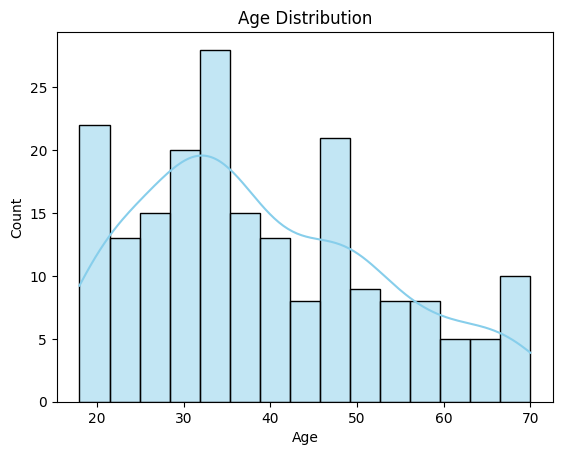

```python
sns.histplot(mall_data['Age'], bins=15, kde=True, color='skyblue')
plt.title('Age Distribution')
plt.show()
```

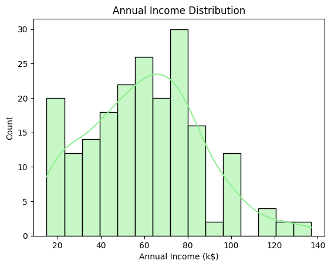

```python
sns.histplot(mall_data['Annual Income (k$)'], bins=15, kde=True, color='lightgreen')
plt.title('Annual Income Distribution')
plt.show()
```

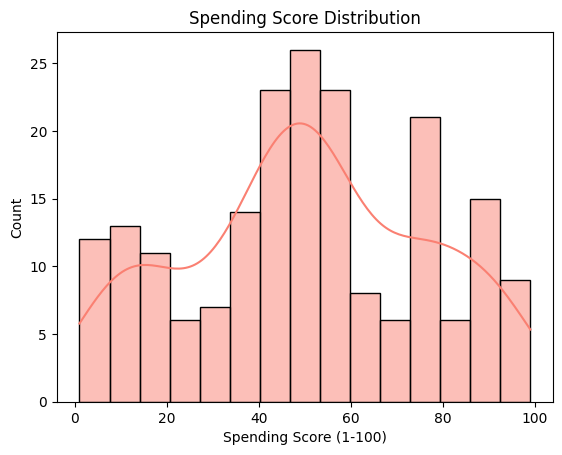

```python
sns.histplot(mall_data['Spending Score (1-100)'], bins=15, kde=True, color='salmon')
plt.title('Spending Score Distribution')
plt.show()
```

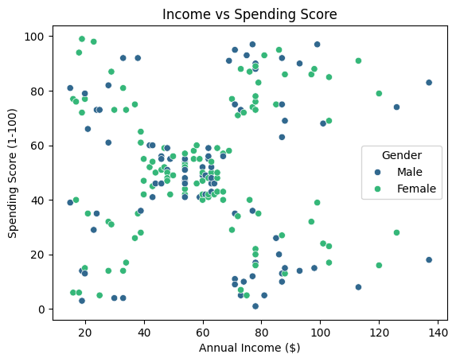

```python
sns.scatterplot(x="Annual Income (k$)" , y='Spending Score (1-100)' , data=mall_data, hue='Gender', palette='viridis')
plt.title("Income vs Spending Score")
plt.xlabel("Annual Income ($)")
plt.show()
```

> By visual inspection of above scatter plot, we can identify 5 possible clusters. But since there is no other information available its very difficult say it with 100% confidence. So we will try to verify this with Elbow method technique.

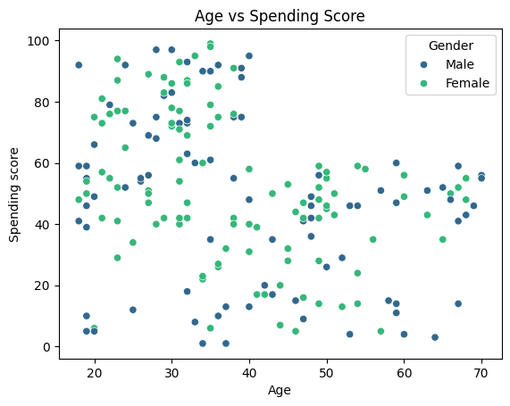

```python
sns.scatterplot(x='Age' , y='Spending Score (1-100)' , data=mall_data, hue ='Gender' , palette='viridis')
plt.title("Age vs Spending Score")
plt.ylabel("Spending score")
plt.show()
```

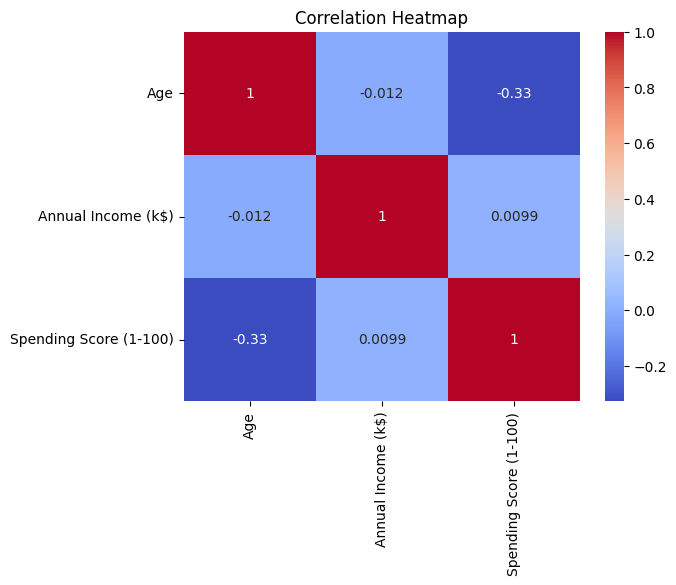

```python
numerical_columns = ['Age', 'Annual Income (k$)', 'Spending Score (1-100)']
corr = mall_data[numerical_columns].corr()
sns.heatmap(corr, annot=True, cmap='coolwarm')
plt.title('Correlation Heatmap')
plt.savefig('Correlation heatmap.png')
plt.show()
```

## 6. K-Means Clustering

#### Choosing The Number of Clusters

The K-Means algorithm depends upon finding the number of clusters and data labels for a pre-defined value of K. To find the number of clusters in the data, we need to run the K-Means clustering algorithm for different values of K and compare the results. So, the performance of K-Means algorithm depends upon the value of K. We should choose the optimal value of K that gives us best performance. There are different techniques available to find the optimal value of K. The most common technique is the elbow method which is described below.

#### Elbow Method

The elbow method is used to determine the optimal number of clusters in K-means clustering. The elbow method plots the value of the cost function produced by different values of K. The below diagram shows how the elbow method works:-

[figure not shown]

We can see that if K increases, average distortion will decrease. Then each cluster will have fewer constituent instances, and the instances will be closer to their respective centroids. However, the improvements in average distortion will decline as K increases. The value of K at which improvement in distortion declines the most is called the elbow, at which we should stop dividing the data into further clusters.

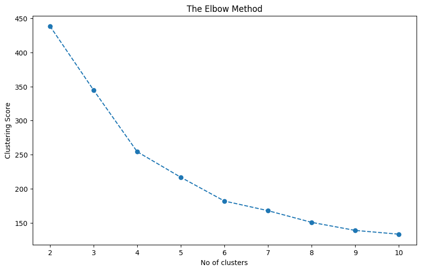

```python
# Finding the no of the clusters
clustering_score = []
for i in range(2,11):
  kmeans= KMeans(n_clusters=i , init='k-means++', n_init=10, random_state=42)
  kmeans.fit(X)
  clustering_score.append(kmeans.inertia_) # inertia_ = Sum of squared distances of samples to their closest cluster center.

#Showing the graph to checki the optimal number of the cluster
plt.figure(figsize=(10,6))
plt.plot(range(2,11) , clustering_score, marker='o', linestyle='--')
plt.title('The Elbow Method')
plt.xlabel('No of clusters')
plt.ylabel('Clustering Score')
plt.savefig('Elbow method.png')
plt.show()
```

> The graph above shows the reduction of a distortion score as the number of clusters increases. However, there is no clear "elbow" visible. It could be either 5 or 6. So, a choice of **5 or 6** clusters seems to be fair.

### 6.1. K-Means Clustering With 5 Clusters

```python
KM_5_clusters = KMeans(n_clusters=5, init='k-means++', n_init=10, random_state=42)

mall_data['Cluster'] = KM_5_clusters.fit_predict(X)
```

```python
print('Number of data points in each cluster: \n', mall_data['Cluster'].value_counts())
```

```
Number of data points in each cluster:
 Cluster
0    58
2    47
1    39
3    34
4    22
Name: count, dtype: int64
```

```python
mall_data.head(10)
```

|  | CustomerID | Gender | Age | Annual Income (k$) | Spending Score (1-100) | Cluster |
| --- | --- | --- | --- | --- | --- | --- |
| 0 | 1 | Male | 19 | 15 | 39 | 2 |
| 1 | 2 | Male | 21 | 15 | 81 | 4 |
| 2 | 3 | Female | 20 | 16 | 6 | 2 |
| 3 | 4 | Female | 23 | 16 | 77 | 4 |
| 4 | 5 | Female | 31 | 17 | 40 | 2 |
| 5 | 6 | Female | 22 | 17 | 76 | 4 |
| 6 | 7 | Female | 35 | 18 | 6 | 2 |
| 7 | 8 | Female | 23 | 18 | 94 | 4 |
| 8 | 9 | Male | 64 | 19 | 3 | 0 |
| 9 | 10 | Female | 30 | 19 | 72 | 4 |

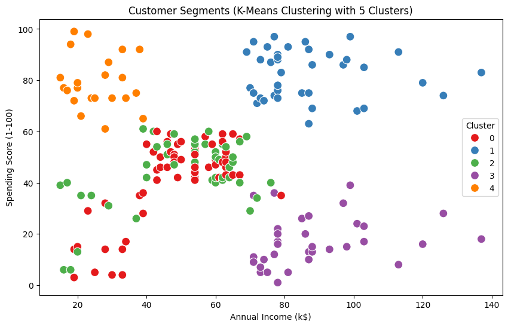

```python
# Visualizing the clusters
plt.figure(figsize=(10,6))

sns.scatterplot(
    x='Annual Income (k$)',
    y='Spending Score (1-100)',
    hue='Cluster',
    data=mall_data,
    s=100,
    palette='Set1'
)

plt.title("Customer Segments (K-Means Clustering with 5 Clusters)")
plt.xlabel('Annual Income (k$)')
plt.ylabel('Spending Score (1-100)')
plt.legend(title='Cluster')
plt.savefig('K-Means Clustering with 5 Clusters.png')
plt.show()
```

It can be seen that there is overlap between **Cluster 0** and **Cluster 2** which indicates that the number of clusters is not ideal.

### 6.2. K-Means Clustering With 6 Clusters

```python
KM_6_clusters = KMeans(n_clusters=6, init='k-means++', n_init=10, random_state=42)

mall_data['Cluster'] = KM_6_clusters.fit_predict(X)
```

```python
print('Number of data points in each cluster: \n', mall_data['Cluster'].value_counts())
```

```
Number of data points in each cluster:
 Cluster
0    45
1    39
5    38
3    34
4    23
2    21
Name: count, dtype: int64
```

```python
mall_data.head(10)
```

|  | CustomerID | Gender | Age | Annual Income (k$) | Spending Score (1-100) | Cluster |
| --- | --- | --- | --- | --- | --- | --- |
| 0 | 1 | Male | 19 | 15 | 39 | 4 |
| 1 | 2 | Male | 21 | 15 | 81 | 4 |
| 2 | 3 | Female | 20 | 16 | 6 | 2 |
| 3 | 4 | Female | 23 | 16 | 77 | 4 |
| 4 | 5 | Female | 31 | 17 | 40 | 2 |
| 5 | 6 | Female | 22 | 17 | 76 | 4 |
| 6 | 7 | Female | 35 | 18 | 6 | 2 |
| 7 | 8 | Female | 23 | 18 | 94 | 4 |
| 8 | 9 | Male | 64 | 19 | 3 | 2 |
| 9 | 10 | Female | 30 | 19 | 72 | 4 |

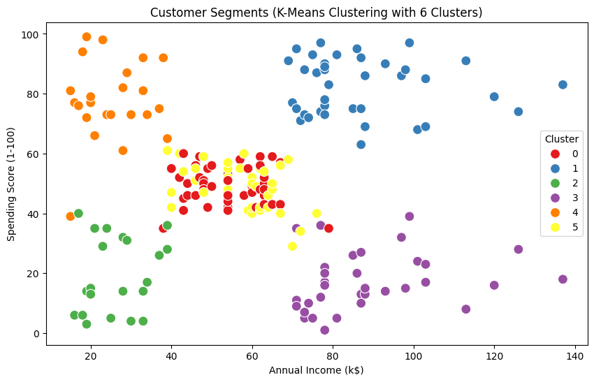

```python
# Visualizing the clusters
plt.figure(figsize=(10,6))

sns.scatterplot(
    x='Annual Income (k$)',
    y='Spending Score (1-100)',
    hue='Cluster',
    data=mall_data,
    s=100,
    palette='Set1'
)

plt.title("Customer Segments (K-Means Clustering with 6 Clusters)")
plt.xlabel('Annual Income (k$)')
plt.ylabel('Spending Score (1-100)')
plt.legend(title='Cluster')
plt.savefig('K-Means Clustering with 6 Clusters.png')
plt.show()
```

### 6.3. K-Means Clustering Conclusion

#### K-Means algorithm generated the following clusters:

##### clients with **low** annual income and **high** spending score

##### clients with **medium** annual income and **medium** spending score

##### clients with **high** annual income and **low** spending score

##### clients with **high** annual income and **high** spending score

##### clients with **low** annual income and **low** spending score

## 7. DBSCAN

In DBSCAN there are two major hyperparameters:

- `eps` : The distance that specifies the neighborhoods. Two points are considered to be neighbors if the distance between them are less than or equal to eps.
- `min_samples`: Minimum number of data points to define a cluster.

It is difficult arbitrarily to say what values will work the best. Therefore, I will be using both random search and grid search for hyperparameter tuning.

`Silhouette Score`: The Silhouette Score evaluates how well each data point fits within its assigned cluster, and how distinctly separated it is from other clusters.

Range: [-1, 1].

- 1: Perfectly matched to its cluster.
- 0: On the boundary.
- -1: Likely assigned to the wrong cluster.

Example: A point with a high score "belongs" firmly to its group; a low score indicates ambiguity.

### 7.1. Random Search

```python
best_score = -1
best_params = {}
n_iter = 50

# Define sampling spaces
eps_values = np.arange(0.1, 1, 0.05)
min_samples_values = range(5, 30)

for i in range(n_iter):
    # Randomly sample a combination
    eps = random.choice(eps_values)
    min_samples = random.choice(min_samples_values)

    # 1. Fit the model
    db = DBSCAN(eps=eps, min_samples=min_samples)
    labels = db.fit_predict(X)

    # Check if a valid clustering was found (more than 1 cluster and not all noise)
    if len(np.unique(labels)) > 1 and -1 in labels and len(np.unique(labels)) > 2:
        # 2. Calculate the Silhouette Score
        score = silhouette_score(X, labels)

        # 3. Track the best result
        if score > best_score:
            best_score = score
            best_params['eps'] = eps
            best_params['min_samples'] = min_samples

print(f"Best Silhouette Score: {best_score}")
print(f"Optimal Parameters: {best_params}")
```

```
Best Silhouette Score: 0.09988386050602471
Optimal Parameters: {'eps': np.float64(0.9500000000000003), 'min_samples': 6}
```

```python
dbscan = DBSCAN(eps=0.95, min_samples=6)
mall_data['DBSCAN_Cluster'] = dbscan.fit_predict(X)
```

```python
print('Number of data points in each cluster: \n', mall_data['DBSCAN_Cluster'].value_counts())
```

```
Number of data points in each cluster:
 DBSCAN_Cluster
 1    110
 0     77
-1     13
Name: count, dtype: int64
```

```python
mall_data.head(10)
```

|  | CustomerID | Gender | Age | Annual Income (k$) | Spending Score (1-100) | DBSCAN_Cluster |
| --- | --- | --- | --- | --- | --- | --- |
| 0 | 1 | Male | 19 | 15 | 39 | -1 |
| 1 | 2 | Male | 21 | 15 | 81 | 0 |
| 2 | 3 | Female | 20 | 16 | 6 | -1 |
| 3 | 4 | Female | 23 | 16 | 77 | 1 |
| 4 | 5 | Female | 31 | 17 | 40 | 1 |
| 5 | 6 | Female | 22 | 17 | 76 | 1 |
| 6 | 7 | Female | 35 | 18 | 6 | 1 |
| 7 | 8 | Female | 23 | 18 | 94 | 1 |
| 8 | 9 | Male | 64 | 19 | 3 | -1 |
| 9 | 10 | Female | 30 | 19 | 72 | 1 |

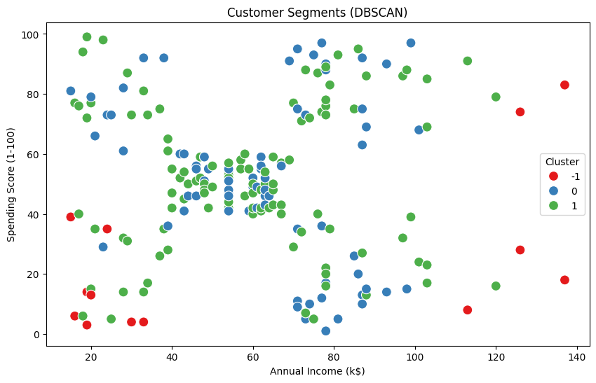

```python
# Visualizing the clusters
plt.figure(figsize=(10,6))

sns.scatterplot(
    x='Annual Income (k$)',
    y='Spending Score (1-100)',
    hue='DBSCAN_Cluster',
    data=mall_data,
    s=100,
    palette='Set1'
)

plt.title("Customer Segments (DBSCAN)")
plt.xlabel('Annual Income (k$)')
plt.ylabel('Spending Score (1-100)')
plt.legend(title='Cluster')
plt.savefig('DBSCAN.png')
plt.show()
```

### 7.2. Grid Search

```python
# Define the parameter grid for DBSCAN
param_grid = {
    'eps': np.arange(0.1, 1.0, 0.1),
    'min_samples': range(5, 11)
}

# Create a DBSCAN model
dbscan = DBSCAN()

# Custom scorer for GridSearchCV using silhouette_score
def dbscan_scorer(estimator, X):
    estimator.fit(X)
    if len(set(estimator.labels_)) > 1:
        return silhouette_score(X, estimator.labels_)
    return -1 # Return a low score if only one cluster is found or all points are noise

# Create a GridSearchCV object
grid_search = GridSearchCV(dbscan, param_grid, scoring=dbscan_scorer, cv=5, n_jobs=-1)

# Fit the GridSearchCV to the scaled data
grid_search.fit(X)

# Get the best parameters
best_params = grid_search.best_params_
print(f"Best Parameters: {best_params}")
print(f"Best Silhouette Score: {grid_search.best_score_}")
```

```
Best Parameters: {'eps': np.float64(0.7000000000000001), 'min_samples': 6}
Best Silhouette Score: 0.2755033016464146
```

```python
# Fit DBSCAN with the best parameters found
best_dbscan = DBSCAN(eps=best_params['eps'], min_samples=best_params['min_samples'])
mall_data['DBSCAN_Cluster'] = dbscan.fit_predict(X)
```

```python
print('Number of data points in each cluster: \n', mall_data['DBSCAN_Cluster'].value_counts())
```

```
Number of data points in each cluster:
 DBSCAN_Cluster
-1    105
 3     18
 2     18
 7     17
 4     15
 5      7
 8      6
 0      5
 1      5
 6      4
Name: count, dtype: int64
```

```python
mall_data.head(10)
```

|  | CustomerID | Gender | Age | Annual Income (k$) | Spending Score (1-100) | DBSCAN_Cluster |
| --- | --- | --- | --- | --- | --- | --- |
| 0 | 1 | Male | 19 | 15 | 39 | -1 |
| 1 | 2 | Male | 21 | 15 | 81 | -1 |
| 2 | 3 | Female | 20 | 16 | 6 | -1 |
| 3 | 4 | Female | 23 | 16 | 77 | 0 |
| 4 | 5 | Female | 31 | 17 | 40 | -1 |
| 5 | 6 | Female | 22 | 17 | 76 | 0 |
| 6 | 7 | Female | 35 | 18 | 6 | -1 |
| 7 | 8 | Female | 23 | 18 | 94 | -1 |
| 8 | 9 | Male | 64 | 19 | 3 | -1 |
| 9 | 10 | Female | 30 | 19 | 72 | 0 |

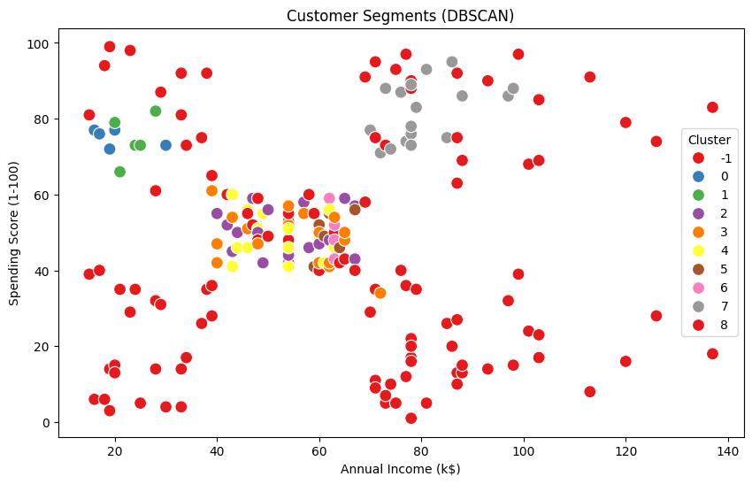

```python
# Visualizing the clusters
plt.figure(figsize=(10,6))

sns.scatterplot(
    x='Annual Income (k$)',
    y='Spending Score (1-100)',
    hue='DBSCAN_Cluster',
    data=mall_data,
    s=100,
    palette='Set1'
)

plt.title("Customer Segments (DBSCAN)")
plt.xlabel('Annual Income (k$)')
plt.ylabel('Spending Score (1-100)')
plt.legend(title='Cluster')
# plt.savefig('DBSCAN.png')
plt.show()
```